# Species Distribution Modeling

Jared Stabach, Smithsonian Conservation Biology Institute

20 August, 2019

## Addax distribution

Addax (*Addax nasomaculatus*) are considered one of the rarest antelopes on earth, with an estimated population of **<100 individuals** in the wild. We assessed the distribution and occurrence of this species from field surveys collected by the [Sahara Conservation Fund](https://www.saharaconservation.org/) over a 7-year period (2008-2014). Our results provide insight into the factors contributing to species occurrence and are guiding field surveys to areas that have the potential to support small and geographically isolated populations of addax. We incorporated field-derived variables of vegetation cover with remote sensing measures of vegetation productivity (NDVI - [Normalized Difference Vegetation Index](https://earthobservatory.nasa.gov/Features/MeasuringVegetation/measuring_vegetation_2.php)) and surface roughness (derived from 30-m SRTM). Models were fit in a generalized linear regression framework to predict and evaluate species occurrence.

## Lab Excercise

In this excercise, we will follow the steps detailed in:

Stabach, J.A., T. Rabeil, V. Turmine, T. Wacher, T. Mueller, and P. Leimgruber. 2017. On the brink of extinction - Habitat selection of addax and dorcas gazelle across the Tin Toumma desert, Niger. Diversity and Distributions 23:581-591.

We will use [R](https://cran.r-project.org/) for all analyses to create a species distribution model, highlighting the variables important in predicting addax occurrence. Like other excercises in [R](https://cran.r-project.org/), we will first load the necessary packages to perform the analyses. Use `help()` for any operations that you don’t understand or that require additional information.

### Load Packages

```r
library(usdm)
library(arm)
library(visreg)
library(pROC)
library(DAAG)
library(fields)
library(MuMIn)
library(gstat)
library(sp)
library(lubridate)
```

### Data File

The raster data layers (NDVI and surface roughness) have already been extracted at plot locations. This has been done to focus on modeling the statistical relationships in this exercise. Building the spatial database, however, is hugely important and should not be overlooked. The layers included in analyses will ultimately depend on your scientific research questions and what is biologically relevant for your species.

NDVI and surface roughness were summarized by calculating the mean value of all pixels within a 2.5-km radius of each plot location (a moving window analysis). Plot locations were spaced at 5-km intervals along line transects. Each line transect varied in length between 50-km and 100-km and were spaced ~10-km apart. Transects were repetitively sampled across years. Information on how to create and extract surface roughness is included as an addendum to this exercise.

All data (including animals counts) were summarized at plot locations. We re-coded animal counts within a 2.5-km radius to a measure of occurrence (i.e, presence/absence). Thus, we modeled the data as a series of 1’s and 0’s, representing addax occurrence at plot locations. Data were aggregated in this fashion because of variability between surveys (i.e., the transects locations didn’t overlap exactly) and because we did not have confidence in the accuracy of the number of individuals recorded at each sighting. In addition, distance to animal sighting locations were only recorded in a subset of the surveys. Sightings >500-m from the transect were removed due to an assumed undercounting bias (confirmed by investigating the frequency of sighthings in relation to distance). This allowed for a conservative broad-scale approach to incorporate extremely messy field data collected over multiple years. See more details in Stabach et al. 2017.

```r
# Load SpatialPointsDataFrame.  Set working directory if necessary.
load(file="Addax_Dataset2.RData")
# Look at data
head(Sub.All2)
```

```
##   Pt_ID       Date YearMonth Id_1        X       Y Addax Dorcas Cornul
## 1     1 2008-12-06    200812   23 767911.0 1742830     0      0      0
## 2     2 2008-12-06    200812   23 770769.0 1744528     0      0      0
## 3     3 2008-12-06    200812   23 776095.8 1747469     0      5      0
## 4     4 2008-12-06    200812   23 780842.3 1750128     0      4      0
## 5     5 2008-12-06    200812   23 785517.3 1752312     0     16      0
## 6     6 2008-12-06    200812   23 790001.9 1754484     0      6      0
##   Stipa1 Stipa2 Human      TRI           TPI    ROUGH Index      ndvi
## 1      0      0     0 2.692203  1.680855e-03 8.343433     1 0.1223870
## 2      0      0     0 2.483226 -9.582118e-05 7.700197     1 0.1219408
## 3      1      0     0 1.617903 -5.089201e-04 5.044250     1 0.1201930
## 4      1      0     0 1.708651  2.159401e-03 5.331611     1 0.1287899
## 5      0      0     0 2.000507  4.656293e-03 6.293324     1 0.1247775
## 6      1      0     0 2.029911  4.920087e-04 6.445662     1 0.1234554
##   Month Season      X.1     Y.1 obsAddax obsDorc Year
## 1    12   Cold 767911.0 1742830        0       0 2008
## 2    12   Cold 770769.0 1744528        0       0 2008
## 3    12   Cold 776095.8 1747469        0       1 2008
## 4    12   Cold 780842.3 1750128        0       1 2008
## 5    12   Cold 785517.3 1752312        0       1 2008
## 6    12   Cold 790001.9 1754484        0       1 2008
```

Columns in the database include *Date* of survey, *X* and *Y* location of each plot, the number of addax and dorcas gazelle (a conspecific) sighted at each location, a unique plot ID (*Pt_ID*), and the presence/absence of vegetation species *Cornulaca monocantha* (Cornul), *Stipagrostis acutiflora* (Stipa1), and *Stipagrostis vulnerans* (Stipa2). These vegetation species were thought *a priori* to influence addax occurence and were collected at each plot location. *Human* disturbance (e.g., footprint, sighting, tire tracks) were also recorded (i.e., *Human* = 1).

Surface roughness (*Rough*) is defined as the change in local elevation range (i.e., the difference between the minimum and maximum values of a cell and its eight surrounding neighbors). *NDVI* (Normalized Difference Vegetation Index) is known to be strongly correlated with a region’s vegetation productivity/greenness and has been used extensively as an important parameter in models predicting animal movement and habitat use. NDVI data (MOD13Q1) was downloaded as 16-day cloud-free data composites with a 250-m resolution.

### Summarize Dataset

Execute a query to estimate the number of surveys conducted each year. Graph the data to visualize the patterns. How would you change the plotting function to visualize the extent of every survey?

```r
# Place data in a table to summarize results.
Unique.ID <- unique(Sub.All2$YearMonth)

# Create matrix to hold everything
dat6 <- matrix(NA,nrow = length(Unique.ID),ncol = 9,dimnames = list(c(),c("YearMonth","Year","Season","PresAddax","PresDorc","PrevAdd","PrevDorc","One","Both")))

for (i in 1:length(Unique.ID)){
    temp <- subset(Sub.All2, YearMonth == Unique.ID[i])
        # Summarize dataset
        dat6[i,1] <- Unique.ID[i]
        dat6[i,2] <- as.character(unique(temp$Year))
        dat6[i,3] <- as.character(unique(temp$Season))
            obs.Add <- ifelse(temp$Addax > 0, 1, 0)
            obs.Dorc <- ifelse(temp$Dorcas > 0, 1, 0)
            Both <- obs.Add + obs.Dorc
            Both2 <- ifelse(Both > 1, 1, 0) # Vector where both present
            One <- ifelse(Both > 0, 1, 0) # At least one species present
        dat6[i,4] <- sum(obs.Add)
        dat6[i,5] <- sum(obs.Dorc)
        dat6[i,6] <- round(sum(obs.Add)/length(obs.Add)*100,digits=1)
        dat6[i,7] <- round(sum(obs.Dorc)/length(obs.Add)*100,digits=1)
        dat6[i,8] <- round(sum(One)/length(obs.Add)*100,digits=1)
        dat6[i,9] <- round(sum(Both2)/length(obs.Add)*100,digits=1)
}

# Look at result.  This should match Table 1 in Stabach et al. 2017.
dat6 <- as.data.frame(dat6)
dat6
```

```
##    YearMonth Year Season PresAddax PresDorc PrevAdd PrevDorc  One Both
## 1     200812 2008   Cold        22       28    33.3     42.4 68.2  7.6
## 2     200906 2009    Dry         6       16     9.1     24.2 28.8  4.5
## 3     200909 2009    Wet         8       19    12.1     28.8 39.4  1.5
## 4     200912 2009   Cold        16       33    24.2       50 63.6 10.6
## 5     201004 2010    Dry         4       15     6.1     22.7 24.2  4.5
## 6     201006 2010    Dry         8       19    12.1     28.8 37.9    3
## 7     201009 2010    Wet         3       13     4.5     19.7 24.2    0
## 8     201012 2010   Cold        14       29    15.9       33 44.3  4.5
## 9     201103 2011    Dry         7        4    15.9      9.1 15.9  9.1
## 10    201107 2011    Wet        10       12    15.2     18.2 24.2  9.1
## 11    201212 2012   Cold         8        9    12.1     13.6 21.2  4.5
## 12    201311 2013   Cold        16       35    24.2       53 60.6 16.7
## 13    201403 2014    Dry         4        9     6.1     13.6 16.7    3
## 14    201409 2014    Wet         4        8     6.1     12.1 18.2    0
## 15    201412 2014   Cold         1       34     1.5     51.5 51.5  1.5
```

```r
# Write to file, if necessary
#write.csv(dat6,file="Addax_Dorcas_Prevalence.csv", quote = FALSE, row.names = FALSE)
```

### Scaling Parameter Values

It is often helpful and necessary to scale continuous parameters that have vastly different value ranges (e.g., elevation and NDVI). Doing so can help with model convergence. While conclusions will remain the same, it is important to remember that data are not on the same scale as the original values and must be back-transformed when making raster predictions. This is critical.

```r
# Scale the parameters...Create a copy of the dataset
Sub.Scale <- Sub.All2

# Use the help(scale) for more information on the function
Sub.Scale$shuman <- as.numeric(scale(Sub.Scale[,"Human"],center=TRUE))
Sub.Scale$sndvi <- as.numeric(scale(Sub.Scale[,"ndvi"],center=TRUE))
Sub.Scale$srough <- as.numeric(scale(Sub.Scale[,"ROUGH"],center=TRUE))
Sub.Scale$sDorcas <- as.numeric(scale(Sub.Scale[,"Dorcas"],center=TRUE))
Sub.Scale$sAddax <- as.numeric(scale(Sub.Scale[,"Addax"],center=TRUE))

# Create a blank matrix to hold the Mean and Standard Deviation of each continuous variable included the dataset.
# These values are essential to rescale to original values
Scale.Val <- matrix(NA, 2, ncol(Sub.Scale[,c(15,17,8,12,7)]), dimnames=list(c("Mn","Sd"),c("Rough","NDVI","Dorcas","Human","Addax")))

# Calculate the mean and standard deviations.
Scale.Val[1,] <- apply(Sub.Scale[,c(15,17,8,12,7)],2,mean)
Scale.Val[2,] <- apply(Sub.Scale[,c(15,17,8,12,7)],2,sd)

# Look at values
Scale.Val
```

```
##       Rough        NDVI    Dorcas     Human    Addax
## Mn 6.618164 0.092855046  2.922222 0.7393939 1.476768
## Sd 1.464744 0.009629818 10.710220 1.8006750 8.336148
```

### Correlation Analysis

Evalute if we have data redundancy. Are there any continuous variables with high levels of correlation? What is a reasonable correlation threshold?

```r
# Group variables together in a dataframe
data.all <- as.data.frame(cbind(Sub.Scale$srough,Sub.Scale$sndvi,Sub.Scale$sDorcas,Sub.Scale$shuman,Sub.Scale$sAddax))

# Variance Inflation Analysis
(eval.vif <- vifstep(data.all))
```

```
## No variable from the 5 input variables has collinearity problem.
##
## The linear correlation coefficients ranges between:
## min correlation ( V5 ~ V3 ):  0.002850639
## max correlation ( V2 ~ V1 ):  -0.3029674
##
## ---------- VIFs of the remained variables --------
##   Variables      VIF
## 1        V1 1.173900
## 2        V2 1.126290
## 3        V3 1.044492
## 4        V4 1.056243
## 5        V5 1.005890
```

## Data Model

### Generalized Linear Regression (GLM)

Model the occurrence of addax in a Generalized Linear Regression (GLM) framework. Our goal here is not necessarily to create the very best model. Instead, we aimed to identify the response of all variables at predicting addax occurrence. We then want to evaluate a submodel that contains only the remote sensing layers to make a prediction of habitat suitability across the landscape. We can easily assess how this ‘submodel’ compares with our ‘full’ model or the ‘best’ model. Why is using a GLM advantageous given the data and objectives?

```r
# Create a full model with all the variables you think are important predictors of addax occurrence
glm.Addax <- glm(obsAddax ~ srough + I(srough^2) + sndvi + I(sndvi^2) + Human + obsDorc + Stipa1 + Stipa2 + Cornul + Season + Year, data = Sub.Scale, family = binomial(link="logit"))
# Summarize result and look at the confidence intervals
summary(glm.Addax)
```

```
##
## Call:
## glm(formula = obsAddax ~ srough + I(srough^2) + sndvi + I(sndvi^2) +
##     Human + obsDorc + Stipa1 + Stipa2 + Cornul + Season + Year,
##     family = binomial(link = "logit"), data = Sub.Scale)
##
## Deviance Residuals:
##     Min       1Q   Median       3Q      Max
## -1.6707  -0.5032  -0.3257  -0.1610   3.1998
##
## Coefficients:
##             Estimate Std. Error z value Pr(>|z|)
## (Intercept)  0.04781    0.43617   0.110 0.912715
## srough       0.92886    0.18762   4.951 7.39e-07 ***
## I(srough^2) -0.67000    0.13669  -4.902 9.50e-07 ***
## sndvi       -0.14342    0.18245  -0.786 0.431830
## I(sndvi^2)  -0.28571    0.10769  -2.653 0.007976 **
## Human       -0.26027    0.11153  -2.334 0.019610 *
## obsDorc1     0.85616    0.25931   3.302 0.000961 ***
## Stipa11     -0.30643    0.25512  -1.201 0.229697
## Stipa21      1.04595    0.26836   3.898 9.71e-05 ***
## Cornul1      0.56465    0.27663   2.041 0.041238 *
## SeasonDry   -0.17105    0.37617  -0.455 0.649327
## SeasonWet   -0.24657    0.34744  -0.710 0.477898
## Year2009    -1.53933    0.51044  -3.016 0.002564 **
## Year2010    -2.14737    0.52032  -4.127 3.67e-05 ***
## Year2011    -2.14421    0.62789  -3.415 0.000638 ***
## Year2012    -2.67330    0.62883  -4.251 2.13e-05 ***
## Year2013    -1.34818    0.50000  -2.696 0.007011 **
## Year2014    -3.95420    0.59485  -6.647 2.98e-11 ***
## ---
## Signif. codes:  0 '***' 0.001 '**' 0.01 '*' 0.05 '.' 0.1 ' ' 1
##
## (Dispersion parameter for binomial family taken to be 1)
##
##     Null deviance: 773.74  on 989  degrees of freedom
## Residual deviance: 606.17  on 972  degrees of freedom
## AIC: 642.17
##
## Number of Fisher Scoring iterations: 6
```

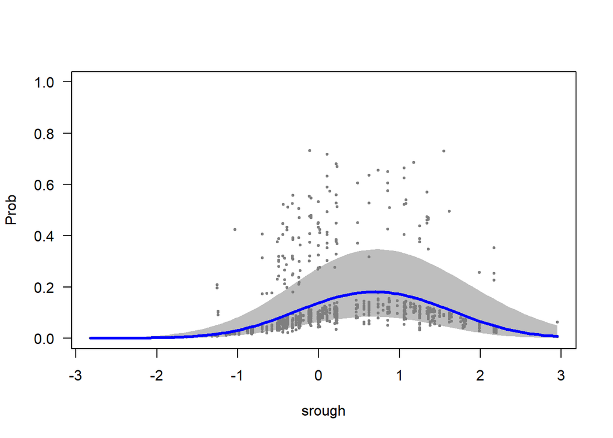

```r
# Graph result for surface roughness
visreg(glm.Addax,"srough",scale="response",ylab="Prob",partial=TRUE,line=list(col="blue"),fill=list(col="gray"),ylim=c(0,1))
```

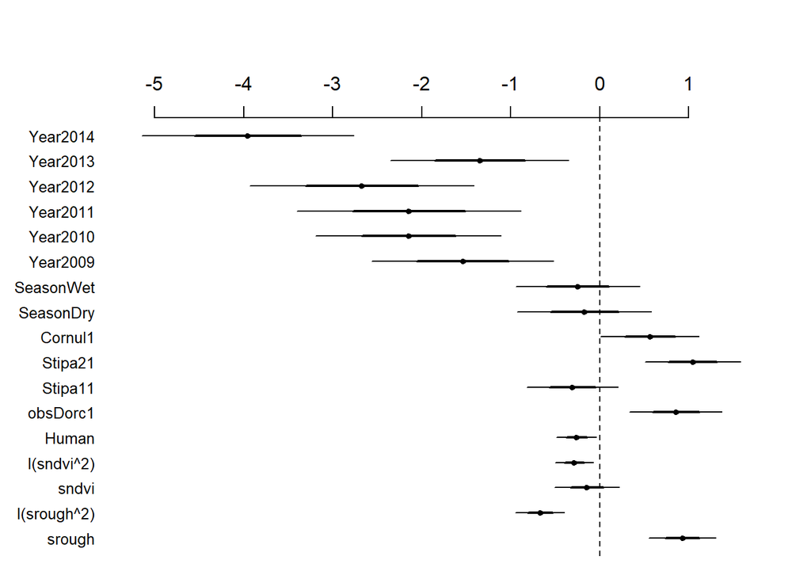

```r
# Plot the coefficients
coefplot(glm.Addax, plot=TRUE, mar=c(1,4,5.1,2), intercept=FALSE, vertical=TRUE, main="", var.las=1, frame.plot=FALSE)
```

### Validation

How good are the models? We can compare our full model to a null model, look at the Area Under the Curve (AUC) statistics. AUC compares the difference between the True Positive Classification Rate and a False Positive Rate (i.e., Specificity vs Sensitivity). Some guidelines to AUC:

- 0.9 - 1: Excellent (A)
- 0.8 - 0.9: Good (B)
- 0.7 - 0.8: Fair (C)
- 0.6 - 0.7: Poor (D)
- 0.5 - 0.6: Fail (F)

```r
# What's the AUC?
predpr <- predict(glm.Addax, type=c("response"))
(roccurve <- roc(Sub.Scale$obsAddax ~ predpr))
```

```
##
## Call:
## roc.formula(formula = Sub.Scale$obsAddax ~ predpr)
##
## Data: predpr in 859 controls (Sub.Scale$obsAddax 0) < 131 cases (Sub.Scale$obsAddax 1).
## Area under the curve: 0.8221
```

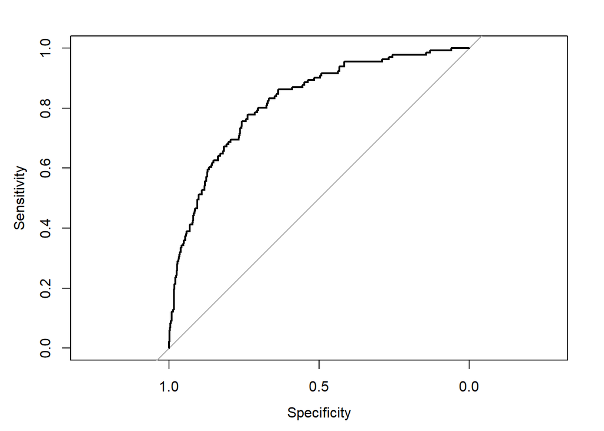

```r
plot(roccurve)
```

## Raster Prediction

One of the most valuable parts of a species distribution model is predicting to locations where surveys were not performed. In order to make a prediction at these locations, we need data that has wall-to-wall coverage. Unfortunately, only two of our layers incorporated in the full model have full coverage (*NDVI* and *Surface Roughness*).

Create a model with these two layers, assessing how the model compares with the full model and predict across the entire study area. As you will see, model statistics indicate that this sub-model is not as good as the full model (compare the AIC, AUC).

The model is still useful, however, as long as we are clear about its shortcomings (i.e., we’d expect the predictive power to be decreased since we are not including the fine scale data collected at individual plot locations).

### Create Model Subset and Evaluate

```r
glm.Addax2 <- glm(obsAddax ~ srough + I(srough^2) + sndvi + I(sndvi^2), data = Sub.Scale, family = binomial(link="logit"))

# Summarize and print confidence intervals
summary(glm.Addax2)
```

```
##
## Call:
## glm(formula = obsAddax ~ srough + I(srough^2) + sndvi + I(sndvi^2),
##     family = binomial(link = "logit"), data = Sub.Scale)
##
## Deviance Residuals:
##     Min       1Q   Median       3Q      Max
## -0.7518  -0.6128  -0.4999  -0.3055   2.9167
##
## Coefficients:
##             Estimate Std. Error z value Pr(>|z|)
## (Intercept) -1.31025    0.13616  -9.623  < 2e-16 ***
## srough       0.63602    0.15559   4.088 4.35e-05 ***
## I(srough^2) -0.55024    0.12642  -4.352 1.35e-05 ***
## sndvi        0.08772    0.12001   0.731   0.4648
## I(sndvi^2)  -0.21425    0.08969  -2.389   0.0169 *
## ---
## Signif. codes:  0 '***' 0.001 '**' 0.01 '*' 0.05 '.' 0.1 ' ' 1
##
## (Dispersion parameter for binomial family taken to be 1)
##
##     Null deviance: 773.74  on 989  degrees of freedom
## Residual deviance: 734.51  on 985  degrees of freedom
## AIC: 744.51
##
## Number of Fisher Scoring iterations: 6
```

```r
# AUC
predpr <- predict(glm.Addax2, type=c("response"))
(roccurve <- roc(Sub.Scale$obsAddax ~ predpr))
```

```
##
## Call:
## roc.formula(formula = Sub.Scale$obsAddax ~ predpr)
##
## Data: predpr in 859 controls (Sub.Scale$obsAddax 0) < 131 cases (Sub.Scale$obsAddax 1).
## Area under the curve: 0.6573
```

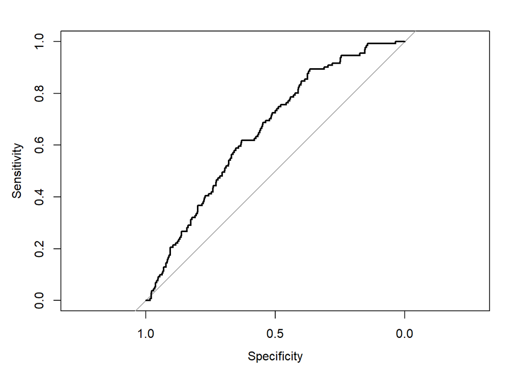

```r
plot(roccurve)
```